# Hva er versjonskontroll?

**Versjonskontroll** er et system for å holde orden på endringer i filer over tid.

Det gjør at man kan:

- se hva som er endret
- se hvem som gjorde endringen
- gå tilbake til tidligere versjoner
- samarbeide uten å overskrive hverandres arbeid

## Tidslinje

```
Versjon 1        Versjon 2        Versjon 3        Versjon 4
Opprettet bok ─▶ Kapittel 1 ─▶ Rettet figur 2 ─▶ Lagt til slides
                                                        │
                                                        │ git push
                                                        ▼
                                                     GitHub
```

## Hvorfor trenger vi versjonskontroll?

> Versjonskontroll motvirker unødvendig redundans

```
rapport.docx
rapport_ny.docx
rapport_ny_ny.docx
rapport_final.docx
rapport_final2.docx
rapport_final_final.docx
```

Etter en stund vet ingen hvilken fil som egentlig er den riktige.

Versjonskontroll løser dette ved å ha:

- én versjon av filene
- en historikk over alle endringer

# Gå tilbake til en tidligere versjon

En av de viktigste fordelene med versjonskontroll er at man kan hente frem tidligere versjoner av et prosjekt.

## Se historikken

For å se tidligere versjoner bruker man:

```
git log
```

Eksempel:

```
a1b2c3d  Lagt til notat i rapport
e4f5g6h  Rettet figur 2
i7j8k9l  Opprettet kapittel 1
```

Hver commit representerer et øyeblikksbilde (*snapshot*) av prosjektet.

## Se en tidligere versjon

Hvis man ønsker å undersøke hvordan prosjektet så ut på et tidligere tidspunkt:

```
git checkout e4f5g6h
```

Da åpnes prosjektet slik det så ut da denne versjonen ble lagret.

For å gå tilbake til den nyeste versjonen:

```
git checkout main
```

## Gjenopprett en fil

Hvis en enkelt fil er blitt ødelagt eller slettet, kan den hentes fra en tidligere versjon:

```
git restore --source=e4f5g6h rapport.md
```

Dette gjenoppretter filen `rapport.md` fra den valgte commiten.

## Angre siste commit

Hvis den siste commiten ikke skal beholdes:

```
git reset --hard HEAD~1
```

Før:

```
Versjon 1
Versjon 2
Versjon 3  ← HEAD
```

Etter:

```
Versjon 1
Versjon 2  ← HEAD
```

> Kommandoen sletter lokale endringer.

## Angre en commit på en trygg måte

Hvis endringene allerede er publisert på GitHub, er det ofte bedre å bruke:

```
git revert a1b2c3d
```

Da oppretter Git en ny commit som opphever endringene fra den tidligere commiten.

Historikken blir:

```
Versjon 1
Versjon 2
Versjon 3
Versjon 4 (angrer versjon 3)
```

## Tidsmaskin-analogien

Git kan betraktes som en tidsmaskin for prosjektet:

```
V1 ── V2 ── V3 ── V4
        ▲
        │
   gå tilbake hit
```

Man kan:

- se tidligere versjoner
- sammenligne versjoner
- hente tilbake gamle filer
- angre feil
- dokumentere utviklingen av prosjektet

## Kommandoer å kjenne til

For de fleste er det nok å kjenne til:

```
git log
git restore
git revert
```

Disse kommandoene gjør det mulig å finne, gjenopprette og angre tidligere endringer uten risiko for å miste hele prosjektet.

### Gå tilbake til tidligere versjoner

```
rapport.docx
      │
      ▼

Versjonskontroll
      |
      ▼

v1 ── v2 ── v3 ── v4 ── v5
 │               │
 └───────────────┘
   kan gå tilbake
```

## Git-analogien

Git tar bilder (*snapshots*) av prosjektet underveis.

For eksempel:

```
Versjon 1: Opprettet boka
Versjon 2: Lagt til kapittel 1
Versjon 3: Rettet figur 2
Versjon 4: Lagt til forelesningsslides
```

Man kan når som helst gå tilbake til en tidligere versjon.

## Eksempel

Legger vi til noe i Git:

```
git add .
git commit -m "Added something to repo"
git push
```

Dette betyr:

- `git add` velger hvilke endringer som skal lagres
- `git commit` oppretter en ny versjon
- `git push` sender versjonen til GitHub

Dermed blir alle endringer dokumentert og sporbare

## Fordeler

Versjonskontroll gjør det mulig å:

- unngå at arbeid går tapt
- eksperimentere uten å være redd for å ødelegge noe
- dokumentere utviklingen av et prosjekt
- samarbeide effektivt med andre
- publisere innhold automatisk gjennom verktøy som GitHub Actions

## Definisjon

> Versjonskontroll er systematisk lagring og sporing av endringer i filer, slik at man kan dokumentere, gjenfinne og samarbeide om utviklingen av et prosjekt.

## Grunnleggende Git-arbeidsflyt

For nybegynnere er det ofte nok å lære:

```
clone
pull
add
commit
push
```

# Git

GitHub ble etablert i 2008 av Tom Preston-Werner, Chris Wanstrath, PJ Hyett og Scott Chacon, og bygger på Git for versjonskontroll og samarbeid. GitHub kjennetegnes ved logoen Mona the octocat, se {numref}`githublogo`. GitHub desktop tilbyr et grafisk grensesnitt for Git. Ikke alle installasjoner av GitHub Desktop inkluderer Git. Det kan derfor være nødvendig å innstallere Git for windows for å få fullt utbytte av Git, som kommandolinjegrensesnitt.

[figure not shown]

Linux-kjernen ble utviklet av Linus Torvalds i 1991 og har pingvinen Tux (Torvalds UniX) som maskot, i {numref}`tux`. Git-logoen med den oransje diamanten, se {numref}`gitlogo`, ble designet av Jason Long i 2012 som en del av en redesign av nettstedet [git-scm.com](https://git-scm.com/). På git-scm.com finner du alt om git. Den oransje diamanten er egentlig et stilisert symbol inspirert av Gits forgreningsmodell (branching). De hvite linjene og sirklene inne i diamanten representerer grener og sammenkoblinger i et Git-repositorium. Jason Long har selv forklart at konseptet var basert på Gits brancher og at han eksperimenterte med ulike rutenett før han landet på den endelige formen. [Utviklingen av Git](https://git-scm.com/book/ms/v2/Getting-Started-A-Short-History-of-Git) sprang ut av en periode preget av både innovasjon og konflikt. Linux-kjerneprosjektet begynte å bruke BitKeeper i 2002. BitKeeper var et distribuert versjonskontrollsystem, men det var proprietær programvare. I 2005 oppstod det en konflikt mellom Linux-miljøet og selskapet BitMover, som utviklet BitKeeper. Da ble den gratis bruken for Linux-kjerneutviklerne avsluttet, og Linus Torvalds bestemte seg for å lage et nytt system: Git.

Git Bash er et kommandolinjeprogram for Windows som inneholder Git og Bash. Bash står for *Bourne Again Shell* og gir tilgang til en rekke kommandoer som brukes til filhåndtering, programmering og versjonskontroll med Git.

[figure not shown]

[figure not shown]

Hvis du allerede har Git installert, kan du sjekke om Git Bash er tilgjengelig ved å søke etter Git Bash i Start-menyen. Hvis Git Bash ikke finnes, installer eller oppdater Git for Windows fra https://gitforwindows.org/, se {numref}`fig-install_bash`. Da får du både Git og Git Bash.

Klikk på Download, som laster ned installasjonsveiviseren.

[figure not shown]

### GNU lisens

Bash er et kommandolinjegrensesnitt (Command Line Interface - CLI) som ble laget i 1989 av Brian Fox som en fri programvare-erstatning for Bourne Shell. Bash ble utviklet som en del av *GNU's not unix* (GNU)-prosjektet startet av Richard Stallman i 1983 for å utvikle fri programvare.

Installasjonsveiviseren for Git for Windows viser lisensvilkårene til GNU General Public Licence. Etter å ha gjennomgått informasjonen kan du fortsette ved å klikke Next.

[figure not shown]

CLI er en måte å bruke et program på ved å skrive kommandoer i et tekstvindu i stedet for å klikke på knapper og menyer. I figuren er et eksempel på kommandoer brukt i Git Bash. Målet var å lage en gratis og fritt tilgjengelig versjon av den opprinnelige Bourne Shell, den klassiske Unix-skallen (sh) utviklet av Stephen Bourne på 1970-tallet.

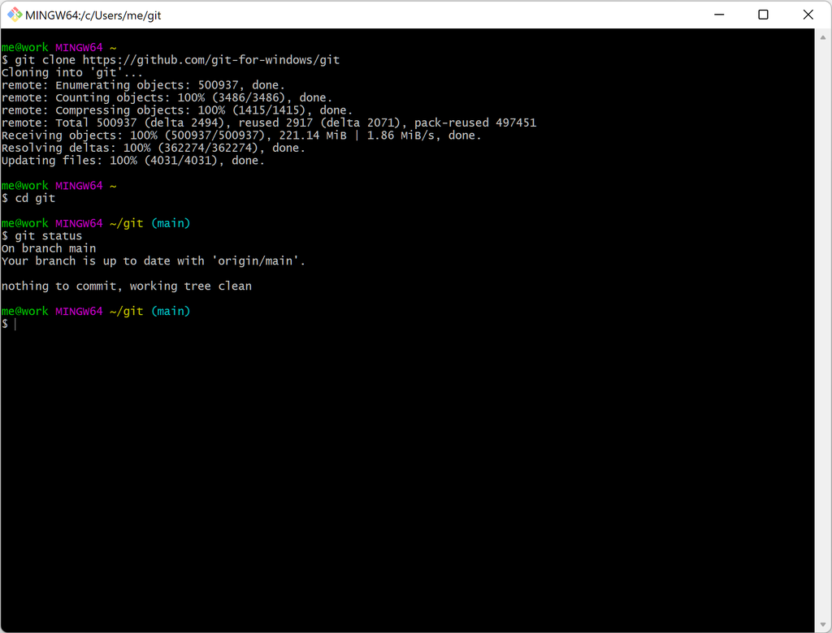

### 1. Last ned Git for Windows

Gå til:

https://gitforwindows.org/

eller:

https://git-scm.com/downloads/win

### 3. Start Git Bash

Etter installasjonen kan du:

- åpne **Git Bash** fra Start-menyen, eller
- høyreklikke i en mappe og velge **Open Git Bash Here**.

### 4. Test installasjonen

Skriv:

```
git --version
```

Eksempel på utskrift:

```
git version 2.51.0.windows.1
```

### 5. Konfigurer navn og e-post

Git lagrer informasjon om hvem som oppretter commits. Derfor må navn og e-post registreres én gang:

```
git config --global user.name "Ditt Navn"
git config --global user.email "din.epost@example.com"
```

Disse opplysningene lagres sammen med alle commits og gjør det mulig å se hvem som har gjort ulike endringer i et prosjekt.

### 6. Klon et repo

```
git clone https://github.com/bruker/repo.git
```

### 7. Oppdater et repo

### Hva gjør `git pull`?

Kommandoen

```
git pull
```

henter de nyeste endringene fra GitHub og oppdaterer den lokale kopien av repoet.

Denne kommandoen brukes når andre har lagt til eller oppdatert filer i repoet, for eksempel nye datasett eller øvingsfiler.

For dette emnet er det i hovedsak disse to kommandoene som brukes:

```
git clone
git pull
```

## Opprette et Git-repo i Git Bash

### 1. Gå til ønsket mappe

```
cd /c/repos
```

### 2. Opprett en ny mappe

```
mkdir dynamiske-kraftsystemer
```

### 3. Gå inn i mappen

```
cd dynamiske-kraftsystemer
```

### 4. Opprett Git-repo

```
git init
```

Du får en melding som ligner:

```
Initialized empty Git repository
```

### 5. Opprett en README-fil

```
echo "# dynamiske-kraftsystemer" > README.md
```

### 6. Legg filen til Git

```
git add README.md
```

### 7. Lag første commit

```
git commit -m "Initial commit"
```

### 8. Koble til GitHub (valgfritt)

Opprett først et tomt repository på GitHub, og koble deretter til:

```
git remote add origin https://github.com/brukernavn/dynamiske-kraftsystemer.git
```

### 9. Last opp til GitHub

```
git branch -M main
git push -u origin main
```

### Nyttige kommandoer

Vis status:

```
git status
```

Legg til alle endringer:

```
git add .
```

Lag commit:

```
git commit -m "Beskrivelse av endringen"
```

Last opp til GitHub:

```
git push
```

Hent siste endringer:

```
git pull
```